# More On Transition Density Function

## More on Transition Density Function

### 1.Definition of Transition Density Function

Given function $$P(W(s),s;W(t),t)\ \ \ \ (1)$$ Where $$0 \leq s \leq T \ \ \ and \ \ 0 \leq t \leq T $$ and $W(x)$ refers to the $state$ of a process at time $t$

Then we can defne $P(W(s),s;W(t),t)$ as the $transition$ $density$ $function$ by $$Prob(a<W(t)<b\ at\ time\ t | at\ W(s)\ at\ time\ s)=\int^{b}_{a}P(W(s),s;W(t),t)dW(t)\ \ \ \ (2)$$

We can interpret it by following statement:

The probability that the variable $W(t)$ lies between $a$ and $b$ at time $t$ in the future, given that it started out with value $W(s)$ at time $s$.

### 2.Forward Equation and Backward Equation

#### 2.1Forward Equation Derivation

Assume that at time $t$, the process reaches the value $y$, and we also assume that the process is subject to a trinomial tree, which is displayed as below.

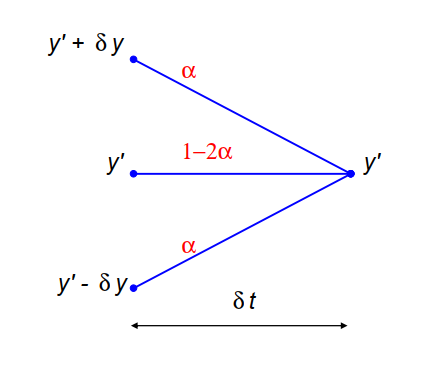

It means for arriving value $y'$ at time $t'$, we can choose 3 forward status as followings:

$$(y'+\Delta y)\ at\ time\ (t'-\Delta t) \ with\ probability \ \alpha \ to\ reach\ \ \ \ (1.1)$$$$y'\ at\ time\ (t'-\Delta t) \ with\ probability \ (1- 2\alpha) \ to\ reach\ \ \ \ (1.2)$$$$(y'-\Delta y)\ at\ time\ (t'-\Delta t) \ with\ probability \ \alpha \ to\ reach\ \ \ \ (1.3)$$

thus, we can have following equation

$$P(y,t;y',t') = \alpha P(y,t;y'+\Delta y,t'-\Delta t) + (1-2\alpha)P(y,t;y',t'-\Delta t) + \alpha P(y,t;y'-\Delta y,t'-\Delta t)\ \ \ \ \ (*2)$$

Using $Taylor\ Expansion$ $$f(x_{0}+\Delta x)= f(x_{0})+f'(x_{0})\Delta x + \frac{1}{2!}f''(x_{0})\Delta x^{2}+ ……\ \ \ \ \ (3.1)$$

or

$$f(x_{0}+\Delta x, y_{0}+\Delta y) = f_{x}(x_0 + y_0)\Delta x + f_y(x_0,y_0)\Delta y + \frac{1}{2!}f_{xx}(x_0,y_0)\Delta x^2 + \frac{1}{2!}f_{yy}(x_{0},y_{0})\Delta y^2 + f_{xy}(x_0,y_0)\Delta x \Delta y + ……\ \ \ \ \ \ (3.2)$$

We can get that $$P(y,t;y'+\Delta y, t'-\Delta t)\approx P(y,t;y',t')-\Delta t \frac{\partial P}{\partial t'}+\Delta y \frac{\partial P}{\partial t'} + \frac{1}{2}\Delta y^{2} \frac{\partial ^2 P}{\partial y'^2}+ …… (4.1)$$

$$P(y,t;y'-\Delta y, t' -\Delta t) \approx P(y,t;y',t')-\Delta t \frac{\partial P}{\partial t'}-\Delta y \frac{\partial P}{\partial y'}+\frac{1}{2}\Delta y^2 \frac{\partial ^2 P}{\partial y'^2}+……(4.2)$$$$P(y,t;y',t'-\Delta t)\approx P(y,t;y',t')-\Delta t \frac{\partial p}{\partial t'} + …… (4.3)$$

$$\Delta t \frac{\partial P}{\partial t'}=\alpha \Delta y^2 \frac{\partial ^2 P}{\partial y'^2}+… \ \ \ \ \ \ (*5.2)$$

or

$$\frac{\Delta P}{\Delta t'}=\alpha \frac{\Delta y^2}{\Delta t}\frac{\Delta ^2 P}{\Delta y'^2}+…\ \ \ \ \ \ (*5.3)$$

Note that $$\displaystyle{\lim_{y \to 0, \Delta t \to 0}\alpha \frac{\Delta y^2}{\Delta t}}\ \ \ \ \ (6.1)$$ should converge to a $finite$ $limit$ to make the process be diffusive In other words, $$O(\Delta y^2) \sim O(\Delta t)\ or\ O(\Delta y) \sim O(\sqrt{\Delta t})$$

Define $$\alpha \frac{\partial y^2}{\Delta t} = c^2 \ \ \ \ \ \ (*6.2)$$

Then $(*5.3)$ becomes

$$\frac{\partial P}{\partial t'} = c^2 \frac{\partial ^2 P}{\partial y'^2} \ \ \ \ (**7)$$

$(**7)$ is known as $Fokker-Planck\ Equation$ or $Forward\ Kolmogorov\ Equation$ (FKE)

#### 2.2 Intepretation for Forward Kolmogorov Equation:

From $$\frac{\partial P}{\partial t'} = c^2 \frac{\partial ^2 P}{\partial y'^2}$$ We can find

(1)This is a PDE with 2 independent variable $y'$ and $t'$

(2)This is a $diffusion$ $equation$

(3)An example of Browian Motion

(4)quantity $c$ is related to volatility

#### 2.3 The Backward Equation Derivation

The derivation still uses the trinomial but in the opposite direction as followings

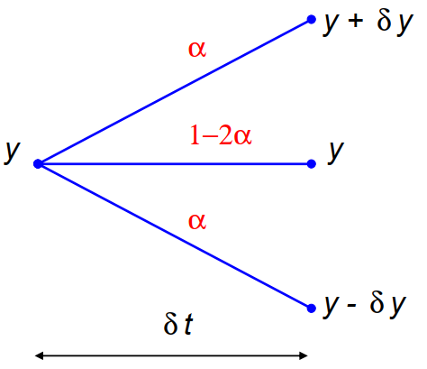

For further discussion we need one another figure as followings

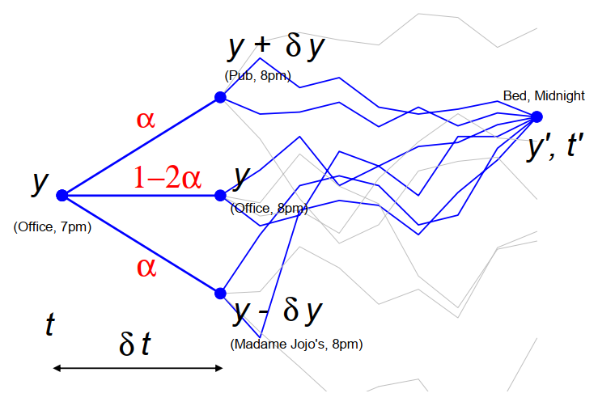

We can find that $$P(y,t;y',t')=\alpha P(y+\Delta y,t+\Delta t; y', t') + (1-2\alpha)P(y,t + \Delta t;y',t')+\alpha P(y-\Delta y,t+\Delta t; y',t')$$

We again use $Taylor\ Expansion$ then we will get $$\frac{\partial P}{\partial t} = -c^2 \frac{\partial ^2 P}{\partial y^2}\ \ \ \ \ \ \ (**8) BackWard$$

Compare with Forward Equation $$\frac{\partial P}{\partial t'} = c^2 \frac{\partial ^2 P}{\partial y'^2} \ \ \ \ (**7) Forward$$ we will find that both of these 2 equations take the same format only change the sign

The solution of the PDEs will be discussed in other documents shared in my Github

## Reference

Paul Wilmott on Quantitative Finance 2nd Edition